# Ice Cover

Paloma Cartwright

20/08/2021

```r
met_madison <- read_csv(here::here("data", "ntl20_v6.csv"), na = "-999")
ice_madison <- read_csv(here::here("data", "ntl33_v7.csv"), na = "-999")
```

Create a visualization that compares ice duration across different lakes in the Madison Lake Area. Include both the actual ice duration values and some representation of summary statistics for each lake.

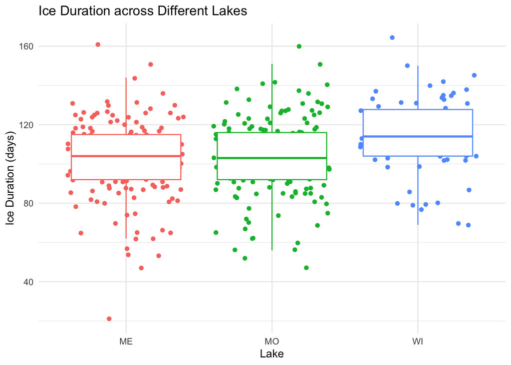

```r
ggplot(ice_madison, aes(x = lakeid, y = ice_duration)) +
  geom_jitter(aes(color = lakeid), show.legend = FALSE) +
  geom_boxplot(aes(color = lakeid), show.legend = FALSE,
               outlier.shape = NA) +
  labs(title = "Ice Duration across Different Lakes",
       x = "Lake",
       y = "Ice Duration (days)") +
  theme_minimal()
```

Find the mean ice cover duration in Madison Lake Area by year.

```r
mean_ice_cover_duration <- ice_madison %>%
  group_by(year = year4) %>%
  summarize(mean = mean(ice_duration, na.rm = TRUE))
```

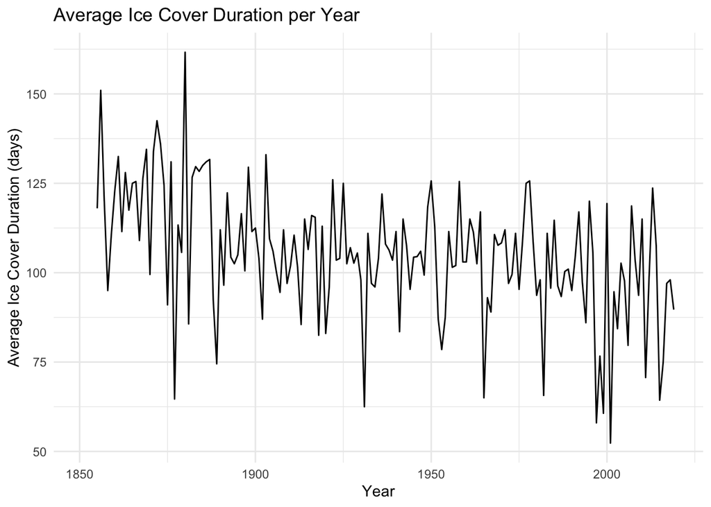

```r
ggplot(mean_ice_cover_duration, aes(x = year, y = mean)) +
  geom_line() +
  theme_minimal() +
  labs(title = "Average Ice Cover Duration per Year",
       x = "Year",
       y = "Average Ice Cover Duration (days)")
```

There is an overall downward trend over time from 1850 to present, even though there is heavy fluctuation between the years.

Find the mean air temperature (using the daily average air temperature - adjusted) in Madison Lake Area by year using only observations from winter months (December, January, February)

```r
mean_air_temp <- met_madison %>%
  filter(month %in% c(12, 1, 2)) %>%
  group_by(year = year4) %>%
  summarize(mean_airtemp = mean(ave_air_temp_adjusted))
```

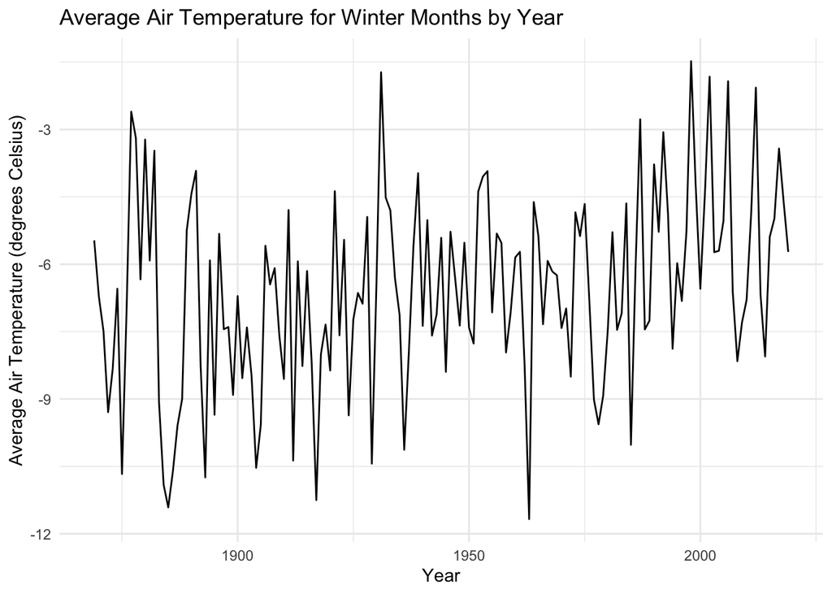

```r
ggplot(mean_air_temp, aes(x = year, y = mean_airtemp)) +
  geom_line() +
  labs(title = "Average Air Temperature for Winter Months by Year",
       x = "Year",
       y = "Average Air Temperature (degrees Celsius)") +
  theme_minimal()
```

There is an overall upward trend of average winter air temperature for the Madison Lake Area, even though there is great yearly fluctuation.

```r
joined_means <- inner_join(mean_ice_cover_duration, mean_air_temp, by = "year")
```

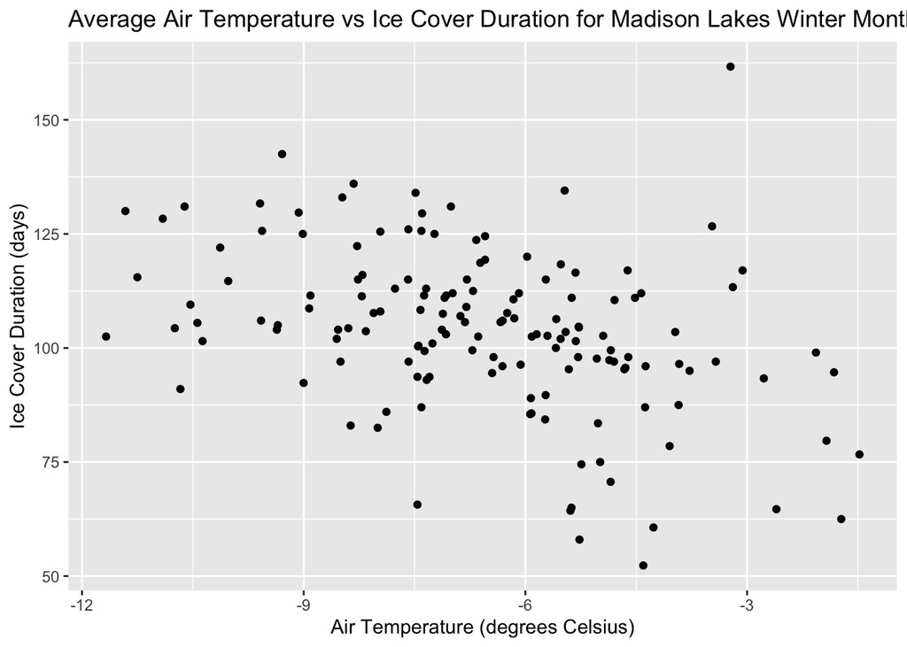

```r
ggplot(joined_means, aes(x = mean_airtemp, y = mean)) +
  geom_point() +
  labs(x = "Air Temperature (degrees Celsius)",
       y = "Ice Cover Duration (days)",
       title = "Average Air Temperature vs Ice Cover Duration for Madison Lakes Winter Months")
```

There is a very weak negative correlation between average yearly air temperature and ice cover duration.

Explore thaw dates since 1970. Create a subset of the ice cover duration data since 1970 (ok to include 1970), then convert the ice_off column to a Date. Use lubridate::yday() to pull the numeric day of the year from that Date. Create an exploratory plot of the ice off day (numeric day-of-the-year) from 1970 - present. Add a sentence or two below this exploratory graph describing the overall trend(s) you observe.

```r
ice_cov_dur <- ice_madison %>%
  filter(year4 >= "1970") %>%
  mutate(ice_off = lubridate::ymd(ice_off)) %>%
  mutate(day_off = lubridate::yday(ice_off))
```

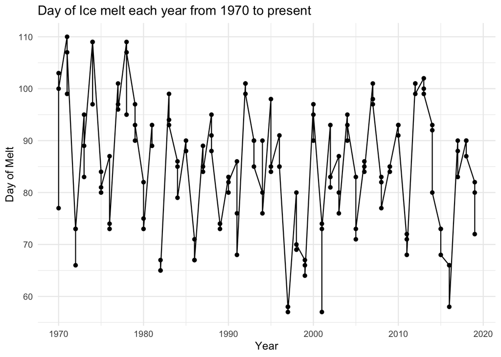

```r
ggplot(ice_cov_dur, aes(x = year4, y = day_off)) +
  geom_line() +
  geom_point() +
  labs(title = "Day of Ice melt each year from 1970 to present",
       x = "Year",
       y = "Day of Melt") +
  theme_minimal()
```

There is no obvious trend in the day of ice melt for the Madison Lake area. There can be a minimal downward trend see but there is a huge range in days of melt. There has been great fluctuation since 1970.